# Научная презентация по лабораторной работе №13

Дисциплина:Операционные системы

Абрамова У. М.

Российский университет дружбы народов, Москва, Россия

Математический институт имени Никольского, Москва, Россия

10.05.2025

# Информация

## Докладчик

- Абрамова Ульяна Михайловна
- Студент НММбд-01-24
- Российский университет дружбы народов
- 1132246782@pfur.ru
- https://github.com/Ulyana-abr

## Цели и задачи

- Научится писать более сложные командные файлы с использованием логических управляющих конструкций и циклов.

## Материалы и методы

- OC-Linux

## Содержание исследования

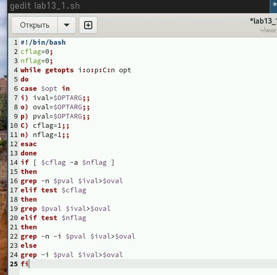

1

## Содержание исследования

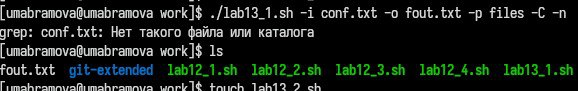

2

## Содержание исследования

2. Напишем сначала на языке Си программу, которая вводит число и определяет, является ли оно больше нуля, меньше нуля или равно нулю. Затем завершим программу при помощи функции exit(n), передавая информацию о коде завершения в оболочку. Командный файл вызовет эту программу и, проанализировав с помощью команды $?, выдаст сообщение о том, какое число было введено (рис. 3, 4, 5).

## Содержание исследования

[figure not shown]

3

## Содержание исследования

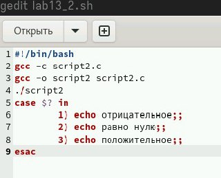

4

## Содержание исследования

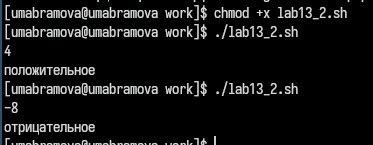

5

## Содержание исследования

3. Напишем командный файл, создающий указанное число файлов, пронумерованных последовательно от 1 до N (рис. 6, 7).

## Содержание исследования

[figure not shown]

6

## Содержание исследования

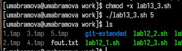

7

## Содержание исследования

4. Напишем командный файл, который с помощью команды tar запаковывает в архив все файлы в указанной директории. Модифицируем его так, чтобы запаковывались только те файлы, которые были изменены менее недели тому назад (рис. 8, 9).

## Содержание исследования

[figure not shown]

8

## Содержание исследования

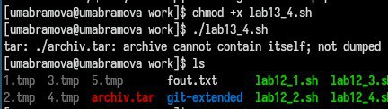

9

## Результаты

- В данной работе мы изучили основы программирования в оболочке ОС UNIX и писать более сложные командные файлы с использованием логических управляющих конструкций и циклов.

## Итоговый слайд

*Чем больше вы практикуетесь и пробуете новое, тем больше и чаще вы будете получать знаний и опыта в разных сферах.*